# SEP_WArefestimates

Tor Kitching

2024-07-23

## Check for Back-Calculated Watershed Areas

The purpose of this document is to provide stock-assessment reference points to the SEP team for back-calculated watershed areas. All code will be drawn from the IWAM function vignette. The following document is originally sourced from “backcalculation_test.RMD” within the IWAM repository. A new version has been made to reflect major updates to the model languages used.

## S1. Data Map

The following function vignette/example is from the IWAM Package Repo hosted publicly through the Pacific Salmon Assess organization available at [this link.](https://github.com/Pacific-salmon-assess/iwam-package)

The package currently utilizes the following data sets:

- *SRinputfile (Private)*: Private data-sets developed by Parken et al. (2006). Required to run the complete function and is available upon request. To be updated with publicly available data. Life histories are included: 1 = ocean type, 0 = stream type. Contains stock names, year, spawners, recruits, and life history identification.
- *WatershedArea (Public)*: Internal input containing watershed areas per stock.
- *CUPars_nBC (Public)*: Input file with Ricker $\alpha$’s without bias correction (CITATION) from Diana Dobson’s Run Reconstruction coded in TMB. Has a higher estimate of Ricker $\alpha$ (lower Sgen).
- *CUPars_wBC (Public)*: Input file with Ricker $\alpha$’s with bias correction (CITATION) from Diana Dobson’s Run Reconstruction coded in TMB. Has a higher estimate of Ricker $\alpha$ (lower Sgen).
- *Backcalc_targetstocks (Public)*: Back-calculated user watershed area input file. Watershed areas calculated based on Parken estimates of SMSY and SREP. All aggregate information; CU, and Inlet, have been removed. PLEASE NOTE: All WCVI stocks use watershed areas with input from WCVI Staff: Nahmint, Sarita, Somass, Bedwell/Ursus, Cypre, Megin, Moyeha, Tranquil, Artlish, Kaouk, Tahsish, Nitinat, Burman, Conuma, Gold, Leiner, Tahsis, Zeballos, Cayeghle, Marble, San Juan, Canton Creek, Espinosa, Kauwinch River, Kleeptee, Little Zeballos River, Malksope River, McKay Cove Creek, Mooyah River, Ououkinsh River, Sucwoa River, Tlupana River, Tsowwin River. PLEASE NOTE: duplicate stock/river names are no acceptable for example in the case of Seymour river - please specify their difference - Georgia Strait vs. South Thompson origins in the river name itself. Duplicate river names will result in a invalid object lengths error when running the IWAM function.

## S2. Models

### S2.a $S_{MAX}$ Model Run

All setup is internal to the IWAM function.

```r
IWAM_smax <- IWAMsmax_rtmb(WAin = c("DataIn/Ordered_backcalculated_noagg.csv"), # Data (INPUT)
                       remove.EnhStocks = FALSE, # Remove Enhancement stocks (INPUT) - DEFAULT
                       run.bootstrap = TRUE, # TRUE/FALSE for running the bootstrap process - DEFAULT
                       bs_seed = 1, # Change the internal seed for the bootstrap (INPUT) - DEFAULT
                       bs_nBS = 1000, # Change the internal number of trials for the bootstrap (INPUT) - DEFAULT
                       # Run 10 for testing purposes - otherwise 20000
                       plot = FALSE # Print plots to DataOut/
)
```

```
## [1] "Lengths checked passed."
## [1] "Lengths checked passed - Ocean life histories."
## [1] "Lengths checked passed - Stream life histories."
## [1] "Both life histories are present and will be combined."
## [1] "Stream and ocean life histories detected, combined, and moved forward."
## [1] "DataOut: rtmb_dataout_target_wEnh"
## [1] "Bootstrapping complete."
```

### S2.b $S_{REP}$ Model Run

All setup is internal to the IWAM function.

```r
IWAM_srep <- IWAMsrep_rtmb(WAin = c("DataIn/Ordered_backcalculated_noagg.csv"), # Data (INPUT)
                           nsim = 1000
)
```

## S3. Tables

This code is a direct lift from the IWAM function vignette. Once the model and bootstrapping has completed, the function will store the following objects:

- `dfout`: A complete data frame containing the SGEN, SREP, and SMSY estimates for each stock and their upper and lower quantiles.

### S3.a IWAM Smax Reference Points Table

*Table 1. IWAM: SGEN, SREP, and SMSY estimates including 0.25% and 97.5% quantiles for all listed stocks. Watershed areas are back-calculated from Parken estimates with the exception of all WCVI stocks, which use original watershed areas: Nahmint, Sarita, Somass, Bedwell/Ursus, Cypre, Megin, Moyeha, Tranquil, Artlish, Kaouk, Tahsish, Nitinat, Burman, Conuma, Gold, Leiner, Tahsis, Zeballos, Cayeghle, Marble, San Juan, Canton Creek, Espinosa, Kauwinch River, Kleeptee, Little Zeballos River, Malksope River, McKay Cove Creek, Mooyah River, Ououkinsh River, Sucwoa River, Tlupana River, Tsowwin River.*

IWAM Smax Model: SGEN, SREP, and SMSY Estimates for All Stocks

| Stock | WA | SGEN | SGEN LQ | SGEN UQ | SREP | SREP LQ | SREP UQ | SMSY | SMSY LQ | SMSY UQ |
| --- | --- | --- | --- | --- | --- | --- | --- | --- | --- | --- |
| South Thompson Agg | 29,565 | 90,000 | 25,000 | 310,000 | 490,000 | 240,000.0 | 1,000,000 | 210,000 | 100,000 | 450,000 |
| Lower Shuswap | 2,663 | 8,400 | 2,100 | 27,000 | 43,000 | 24,000.0 | 73,000 | 19,000 | 10,000 | 34,000 |
| Middle Shuswap | 640 | 2,100 | 470 | 6,100 | 10,000 | 5,700.0 | 18,000 | 4,500 | 2,500 | 8,000 |
| Wap | 20 | 56 | 11 | 200 | 300 | 130.0 | 720 | 130 | 52 | 300 |
| East | 46 | 130 | 33 | 440 | 710 | 330.0 | 1,500 | 300 | 140 | 670 |
| Goodspeed | 15 | 41 | 10 | 180 | 220 | 85.0 | 540 | 95 | 36 | 250 |
| Keith | 56 | 170 | 36 | 550 | 860 | 380.0 | 1,800 | 370 | 170 | 800 |
| Klaskish | 41 | 110 | 27 | 400 | 620 | 290.0 | 1,400 | 260 | 120 | 580 |
| Mahatta | 114 | 330 | 84 | 1,100 | 1,800 | 910.0 | 3,400 | 760 | 380 | 1,500 |
| Washlawlis | 23 | 65 | 16 | 240 | 350 | 150.0 | 800 | 150 | 63 | 340 |
| Colonial&Cayeagle | 79 | 240 | 60 | 790 | 1,200 | 610.0 | 2,600 | 530 | 260 | 1,100 |
| Marble | 168 | 500 | 130 | 1,700 | 2,700 | 1,300.0 | 5,100 | 1,100 | 570 | 2,200 |
| Adam | 279 | 820 | 210 | 2,700 | 4,400 | 2,400.0 | 8,100 | 1,900 | 970 | 3,600 |
| Amor de Cosmos | 15 | 43 | 9 | 150 | 220 | 84.0 | 560 | 95 | 37 | 240 |
| Cluxewe | 90 | 260 | 70 | 870 | 1,400 | 660.0 | 2,900 | 600 | 280 | 1,200 |
| Kokish | 104 | 300 | 74 | 940 | 1,600 | 830.0 | 3,000 | 700 | 350 | 1,300 |
| Quatse | 80 | 240 | 54 | 780 | 1,200 | 590.0 | 2,500 | 530 | 250 | 1,100 |
| Nimpkish (above Lake) | 400 | 1,200 | 280 | 3,800 | 6,200 | 3,400.0 | 12,000 | 2,700 | 1,400 | 5,200 |
| Salmon | 912 | 2,600 | 640 | 8,300 | 15,000 | 8,200.0 | 25,000 | 6,200 | 3,400 | 11,000 |
| Quinsam-Campbell | 171 | 480 | 130 | 1,500 | 2,600 | 1,300.0 | 5,300 | 1,100 | 550 | 2,300 |
| Conuma | 20 | 61 | 13 | 210 | 310 | 140.0 | 750 | 130 | 58 | 320 |
| Tahsis | 77 | 220 | 52 | 730 | 1,200 | 570.0 | 2,400 | 500 | 240 | 1,100 |
| Burman | 70 | 220 | 48 | 710 | 1,100 | 530.0 | 2,300 | 470 | 220 | 1,000 |
| Artlish | 64 | 180 | 45 | 660 | 990 | 450.0 | 2,100 | 430 | 190 | 930 |
| Kaouk | 101 | 310 | 78 | 1,100 | 1,600 | 800.0 | 3,400 | 680 | 340 | 1,500 |
| Tahsish | 172 | 530 | 130 | 1,500 | 2,700 | 1,400.0 | 5,200 | 1,200 | 570 | 2,300 |
| Gold | 856 | 2,700 | 650 | 7,900 | 14,000 | 7,800.0 | 24,000 | 5,900 | 3,300 | 10,000 |
| Leiner | 109 | 320 | 86 | 960 | 1,700 | 840.0 | 3,300 | 720 | 360 | 1,500 |
| Zeballos | 194 | 570 | 130 | 1,900 | 3,000 | 1,600.0 | 5,600 | 1,300 | 680 | 2,400 |
| Amai | 14 | 41 | 9 | 160 | 210 | 84.0 | 540 | 91 | 35 | 240 |

[output cut: 85 more lines]

### S3.b IWAM Srep Reference Points Table

*Table 2. IWAM Srep Model: SGEN, SREP, and SMSY estimates including quantiles for all listed stocks. (See above Table 1 description.*

|  | Stock | WA | LH | SGEN | SGEN LQ | SGEN UQ | SREP | SREP LQ | SREP UQ | SMSY | SMSY LQ | SMSY UQ |
| --- | --- | --- | --- | --- | --- | --- | --- | --- | --- | --- | --- | --- |
| V1 | South Thompson Agg | 29,565 | 1 | 34,124 | 13,688 | 69,451 | 398,020 | 137,363 | 1,153,296 | 159,668 | 81,143 | 284,035 |
| V2 | Lower Shuswap | 2,663 | 1 | 3,245 | 1,343 | 6,596 | 38,826 | 18,669 | 80,749 | 15,401 | 7,712 | 27,340 |
| V3 | Middle Shuswap | 640 | 1 | 818 | 331 | 1,727 | 9,779 | 4,735 | 20,194 | 3,895 | 1,986 | 7,263 |
| V4 | Wap | 20 | 1 | 29 | 12 | 64 | 339 | 97 | 1,187 | 137 | 68 | 257 |
| V5 | East | 46 | 1 | 66 | 26 | 137 | 770 | 261 | 2,277 | 311 | 153 | 560 |
| V6 | Goodspeed | 15 | 1 | 21 | 9 | 44 | 251 | 67 | 938 | 101 | 51 | 181 |
| V7 | Keith | 56 | 1 | 78 | 31 | 165 | 925 | 324 | 2,639 | 370 | 181 | 697 |
| V8 | Klaskish | 41 | 1 | 58 | 22 | 114 | 680 | 225 | 2,061 | 272 | 133 | 485 |
| V9 | Mahatta | 114 | 1 | 158 | 63 | 330 | 1,840 | 730 | 4,637 | 749 | 364 | 1,372 |
| V10 | Washlawlis | 23 | 1 | 34 | 14 | 67 | 393 | 116 | 1,332 | 160 | 75 | 289 |
| V11 | Colonial&Cayeagle | 79 | 1 | 112 | 43 | 236 | 1,287 | 480 | 3,453 | 527 | 259 | 976 |
| V12 | Marble | 168 | 1 | 229 | 87 | 501 | 2,676 | 1,127 | 6,358 | 1,084 | 516 | 1,975 |
| V13 | Adam | 279 | 1 | 372 | 150 | 739 | 4,383 | 1,973 | 9,738 | 1,764 | 902 | 3,233 |
| V14 | Amor de Cosmos | 15 | 1 | 21 | 9 | 43 | 251 | 67 | 938 | 100 | 48 | 177 |
| V15 | Cluxewe | 90 | 1 | 124 | 50 | 254 | 1,460 | 557 | 3,830 | 590 | 291 | 1,137 |
| V16 | Kokish | 104 | 1 | 141 | 60 | 289 | 1,684 | 658 | 4,309 | 673 | 343 | 1,197 |
| V17 | Quatse | 80 | 1 | 108 | 45 | 222 | 1,303 | 487 | 3,488 | 516 | 257 | 940 |
| V18 | Nimpkish (above Lake) | 400 | 1 | 528 | 214 | 1,116 | 6,213 | 2,904 | 13,290 | 2,487 | 1,204 | 4,503 |
| V19 | Salmon | 912 | 1 | 1,188 | 504 | 2,574 | 13,771 | 6,768 | 28,022 | 5,631 | 2,771 | 10,419 |
| V20 | Quinsam-Campbell | 171 | 1 | 232 | 96 | 477 | 2,723 | 1,149 | 6,451 | 1,082 | 554 | 1,980 |
| V21 | Conuma | 20 | 1 | 29 | 12 | 60 | 338 | 97 | 1,184 | 138 | 65 | 248 |
| V22 | Tahsis | 77 | 1 | 105 | 44 | 223 | 1,261 | 468 | 3,396 | 501 | 251 | 923 |
| V23 | Burman | 70 | 1 | 101 | 40 | 220 | 1,149 | 420 | 3,148 | 477 | 238 | 877 |
| V24 | Artlish | 64 | 1 | 90 | 38 | 181 | 1,048 | 376 | 2,921 | 425 | 217 | 782 |
| V25 | Kaouk | 101 | 1 | 137 | 56 | 305 | 1,633 | 635 | 4,201 | 652 | 314 | 1,220 |
| V26 | Tahsish | 172 | 1 | 230 | 97 | 480 | 2,745 | 1,160 | 6,497 | 1,084 | 558 | 1,935 |
| V27 | Gold | 856 | 1 | 1,096 | 460 | 2,333 | 12,963 | 6,359 | 26,425 | 5,206 | 2,627 | 9,763 |
| V28 | Leiner | 109 | 1 | 155 | 63 | 334 | 1,770 | 698 | 4,492 | 725 | 363 | 1,328 |
| V29 | Zeballos | 194 | 1 | 262 | 108 | 538 | 3,082 | 1,325 | 7,173 | 1,236 | 602 | 2,297 |
| V30 | Amai | 14 | 1 | 20 | 8 | 43 | 237 | 63 | 895 | 96 | 46 | 177 |

[output cut: 85 more lines]

## S4. Comparative Plotting

The objective of this section is to provide comparison figures between the IWAM function’s estimates of SMSY and SREP to the Parken model estimates. The following plots have been limited to a maximum Smsy and Srep value of 25,000 in order to match those of the technical working group presentations.

### S4.a Stockwise

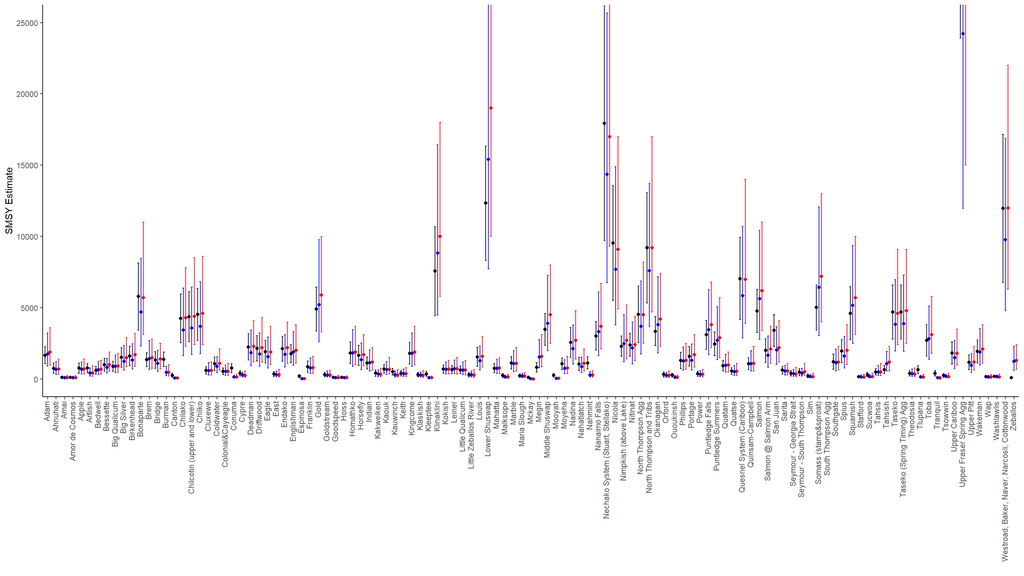

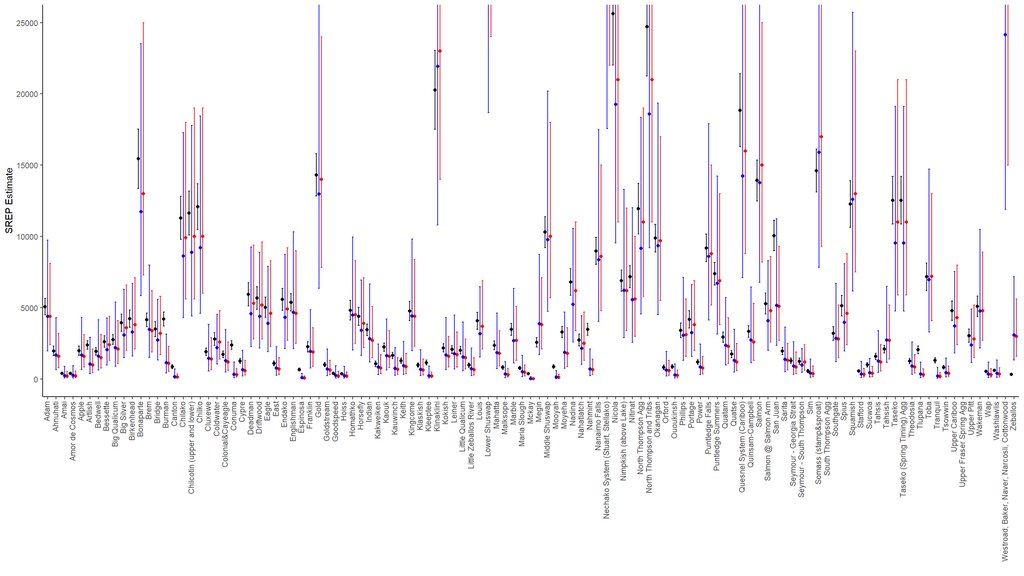

### S4.b Regression

The point of this plotting exercise is to show where the back-calculated estimates fall in relation to the “training”/synoptic dataset.

```r
# copy from IWAM_Nimblemodel.RMD - watch transformations
```